# Introduction to Poisson Regression

Lu Li

December 16, 2015

Now, we will introduce more on the theoretical side of Poisson Regression.

Recall that a discrete random variable $X$ is said to have a Poisson distribution with parameter $\lambda$ > 0, if, for k = 0, 1, 2, …, the probability mass function of $X$ is given by $f(k;\lambda )=\Pr(X=k)={\frac {\lambda ^{k}e^{-\lambda }}{k!}}$

with $E(X) = Var(X) = \lambda$.

Here is a plot of the probability mass function of Poisson distribution with different value of $\lambda$.

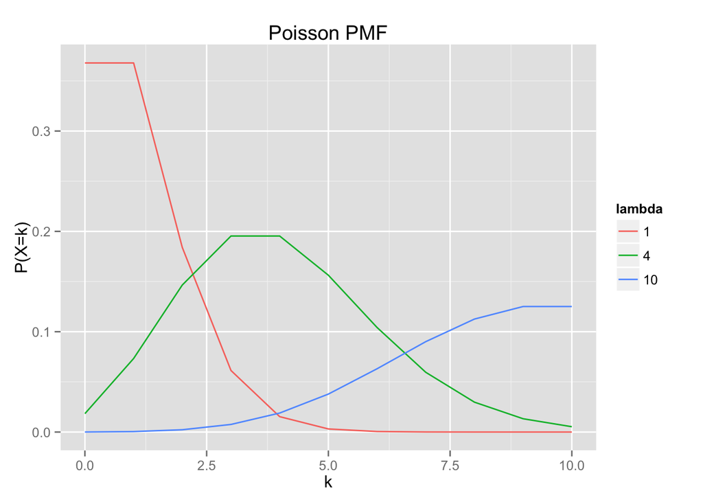

### Three components of GLM

- A probability distribution
- A linear predictor $\eta = X\beta$
- A link function $g$ such that $E(Y) = \mu = g^{-1}(\eta)$

In Poisson regression, we usually choose the link function to be $\log$.

### GLM Model for Counts

Assume that $g(\mu)=\beta_0+\beta_1X_1+\beta_2X_2+…+\beta_kX_k=X^T_i\beta$

Here, the response $Y$ has a Poisson distribution that is $y_i$ ~ $Poisson(\mu_i)$ for $i=1,...,N$ where the expected count of $y_i$ is $E(Y)=\mu$.

For simplicity, with a single explanatory variable and log link function, we write: $\log(\mu)=\alpha+\beta X.$ This is equivalent to: $\mu=\exp(\alpha+\beta X)=\exp(\alpha)\exp(\beta X)$.

### GLM Model for Rates

Assume that $g(\mu)=\beta_0+\beta_1X_1+\beta_2X_2+…+\beta_kX_k=X^T_i\beta$

Here, the response $Y$ has a Poisson distribution, and $t$ is the index of the time or space; more specifically the expected value of rate $Y/t$, is $E(Y/t)=\mu$ that is $E(Y)=\mu t$.

With the same log link function, we have $\log(\mu/t)=\alpha+\beta X$, which is equivalent to $\log(\mu)−\log(t)=\alpha+\beta X$ $\log(\mu)=\alpha+\beta X+ \log(t)$

We call $\log(t)$ an offset term. It is an adjustment term and a group of observations may have the same offset, or each individual may have a different value of $t$.

### Parameter Estimation

We can find the Maximum Likelihood Estimator(MLEs) for $\beta$ by maximizing the log-likelihood. In general, there are no closed-form solutions, so the ML estimates are obtained by using iterative algorithms such as Newton-Raphson (NR), Iteratively re-weighted least squares (IRWLS), etc.

Example:

Response: $Y_1, Y_2, ..., Y_n$

Explanatory Variable: $X_1, X_2, ..., X_n$

$Y_i|\mu_i$ ~ Poisson($\mu_i$), $\eta_i = \log(\mu_i) = X^T_i \beta$

The log-likelihood can be written as: $l(\mu,y) = \sum_i(y_i\log(\mu_i)-\mu_i)+constant = \sum_i (y_i X^T_i \beta - \exp(X^T_i \beta))+c$

By calculating the first and second derivative of $l(\mu,y)$ with respect to $\beta$, we can derive the formula for N-R method: ($W = diag(\mu_i)$)

$\beta_{i+1} = \beta_i + (X^TWX)^{-1}X^T(y-\mu)$

### Model Fit

#### Residual analysis

- Pearson residual: $(y_i-\mu_i)/\sqrt{\mu_i}$
- deviance residual: $sgn(y_i-\mu_i)\sqrt{2(y_i\log(y_i/\mu_i)-(y_i-\mu_i))}$
- etc…

#### Overdispersion:

- A Poisson distribution has the same mean and variance
- Overdispersion means that observed variance is larger than the assumed variance, i.e., Var(Y)=$\phi \mu$ where $\phi$ is a scale parameter
- We can either adjust for overdispersion or use negative binomial regression instead

### GLM in R

In R, we can use the function glm() to fit the model, and many options are available to refine the model.